# Discussion 5

Po

10/27/2020

# Logistics

[Piazza](https://piazza.com/uc_davis/fall2020/sta137/home)

# ACF, PACF

## AR(2)

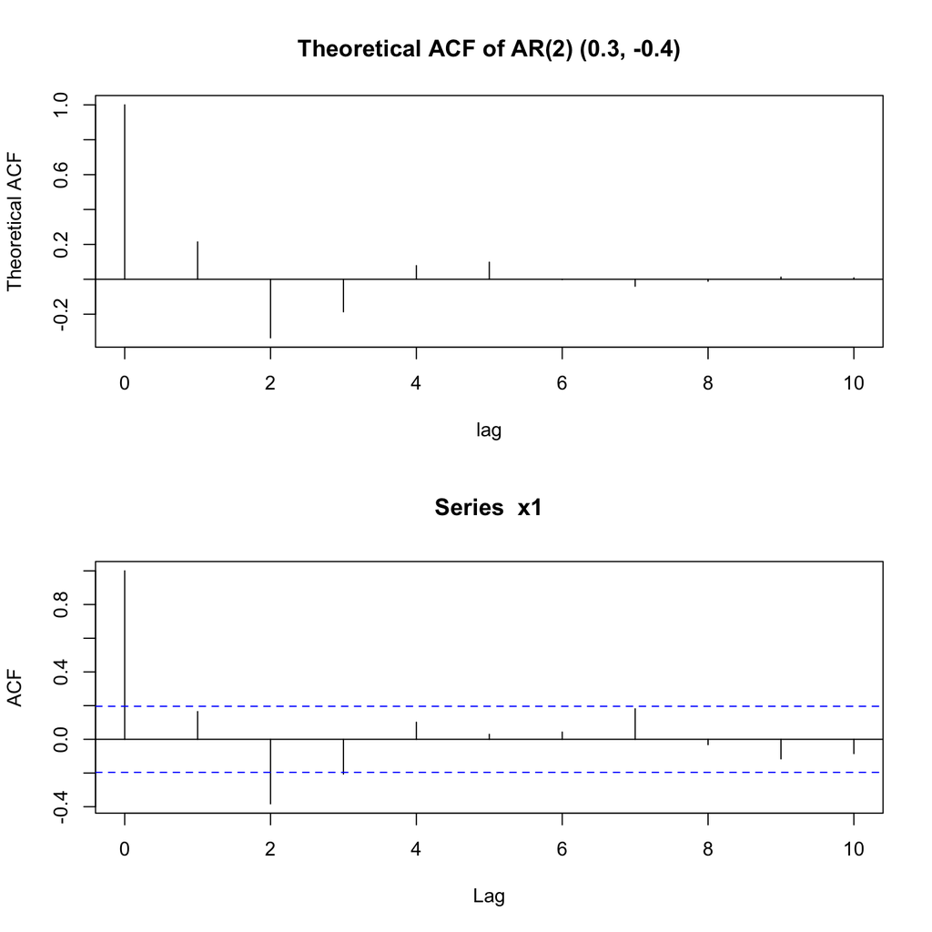

```r
x1 = arima.sim(list(ar=c(0.3, -0.4)), n=100)
par(mfrow=c(2,1))
plot(0:10, ARMAacf(ar=c(0.3, -0.4), lag.max = 10),
     type = "h",
     xlab = "lag",
     ylab = "Theoretical ACF",
     main = "Theoretical ACF of AR(2) (0.3, -0.4)"
     )
abline(h = 0)
acf(x1, lag.max = 10)
```

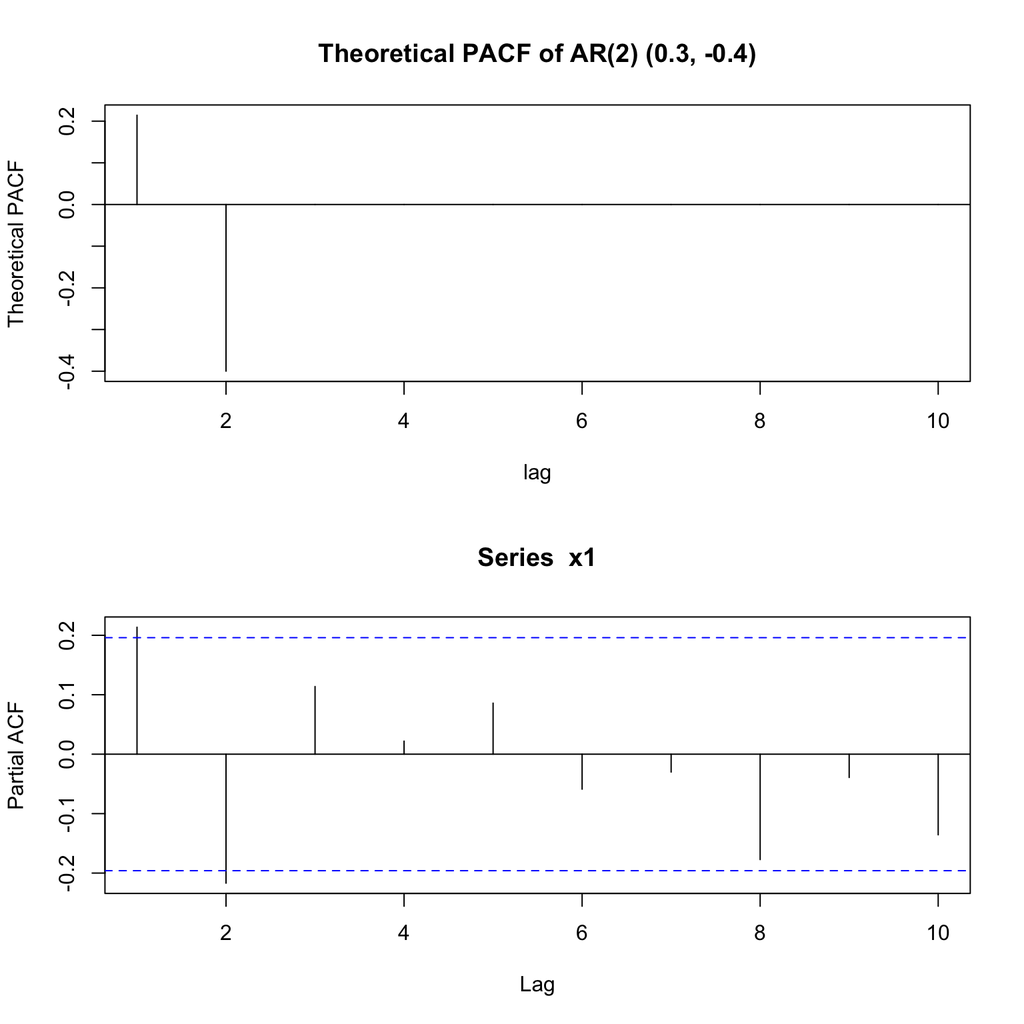

```r
x1 = arima.sim(list(ar=c(0.3, -0.4)), n=100)
par(mfrow=c(2,1))
plot(1:10, ARMAacf(ar=c(0.3, -0.4), lag.max = 10, pacf=TRUE),
     type = "h",
     xlab = "lag",
     ylab = "Theoretical PACF",
     main = "Theoretical PACF of AR(2) (0.3, -0.4)"
     )
abline(h = 0)
pacf(x1, lag.max = 10)
```

## MA(2)

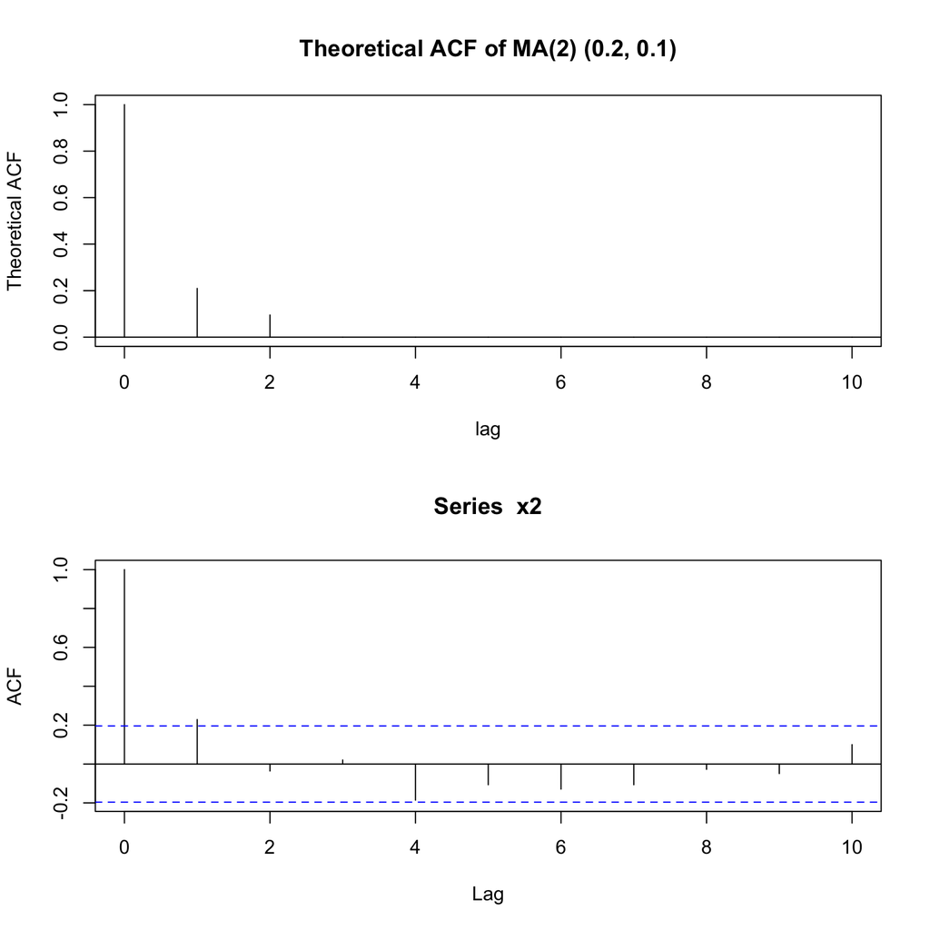

```r
x2 = arima.sim(list(ma=c(0.2, 0.1)), n=100)
par(mfrow=c(2,1))
plot(0:10, ARMAacf(ma=c(0.2, 0.1), lag.max = 10),
     type = "h",
     xlab = "lag",
     ylab = "Theoretical ACF",
     main = "Theoretical ACF of MA(2) (0.2, 0.1)"
     )
abline(h = 0)
acf(x2, lag.max = 10)
```

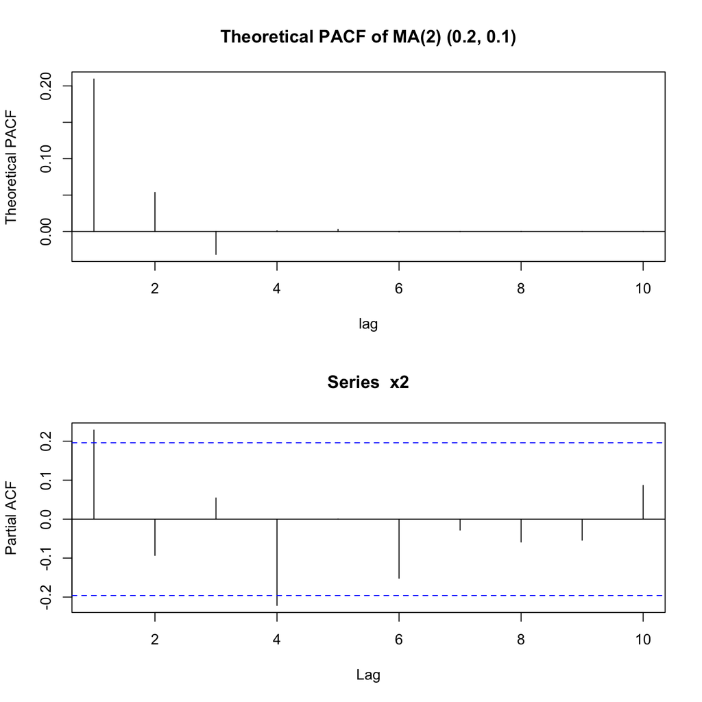

```r
par(mfrow=c(2,1))
plot(1:10, ARMAacf(ma=c(0.2, 0.1), lag.max = 10, pacf=TRUE),
     type = "h",
     xlab = "lag",
     ylab = "Theoretical PACF",
     main = "Theoretical PACF of MA(2) (0.2, 0.1)"
     )
abline(h = 0)
pacf(x2, lag.max = 10)
```

# HW4

- 1a Show $X_t = \sum_{j=0}^t \phi^j Z_{t-j}$.
- 1b/c Show $\text{Cov}(X_{t+h}, X_t) = \phi^h \text{Var}(X_t)$.
- 2 Show $\rho(1) = \frac{\theta}{1+\theta^2}$. What is $\text{Cov}(X_{t+2} - \rho(1) X_{t+1}, X_{t} - \rho(1) X_{t+1})$?
- 4 WTF? TBH the wording in this question is too fancy I don’t comprehend this neither. Let me tell you the solution directly. It is in fact
  $$X_{n+2} = \phi^2_1 X_n + \phi_1 \phi_2 X_{n-1} + \phi_1 w_{n+1} + w_{n+2}$$
  and thus
  $$E[(X_{n+2} - \phi^2_1 X_n - \phi_1 \phi_2 X_{n-1})]
  =
  0 \quad \text{for all } k = 1, 2, \dots, n$$
  From all the above equations, you can guess the formula for $X^n_{n+2}$. Please fill in the missing mathematical arguments and conclusion. Blindly copy and paste above sentences as solution will get zero mark.

# Rmarkdown

Hey, most of the project submissions are very uglily written. Your answers would be easily overlooked if you just throw all raw R outputs and treat them as answers. If your answer is sitting inside raw R output and is also unfortunately missed, it will NOT credited :(.

There are some resources of RMarkdown for you to learn better organizing your work.

- https://bookdown.org/yihui/rmarkdown/
- https://r4ds.had.co.nz/r-markdown.html
- https://www.google.com/search?q=Rmarkdown